# Extracting normalized difference vegetation index (NDVI) time series data from Landsat images via R-spatial Packages

April 23, 2019

# 1 Introduction

## 1.1 Background

## 1.2 Why landsat images

## 1.3 Objectives

- to learn how to deal with remotely sensed images to extract physical quantities like NDVI
- to visualize rater image and relevant statistics
- to perform sample raster calculation
- to extract NDVI time series from deifferent periods of obesevation
- to visualize spatial dynamics

## 1.4 How to download

[output not shown]

# 2 Download Landsat Images

- download image via `google drive` or in the links
- make sure all the files are under data folder
- note that all the image files named with “YYYYMMDD.tif” format

# 3 Loading libraries

```r
library(raster)
library(sp)
library(rgdal)
```

```r
library(ggplot2)
library(ggpubr)
library(knitr)
```

# 4 Costumized functions

```r
NDVI <- function(X, Y){
  #X: Near infrared band Image
  #Y: Red band Image
  ndvi <- (X-Y)/(X+Y)
  return(ndvi)
}

ggrasterPlot <- function(imgRaster, valueStr, titleStr, colorScheme =  'inferno'){
  imgRaster.df <- as.data.frame(imgRaster, xy = TRUE)
  colnames(imgRaster.df)<-c('x', 'y', valueStr)
  pltRaster<-ggplot(imgRaster.df, aes(x = x, y = y)) +
    geom_raster(data = imgRaster.df , aes_string(fill = valueStr)) +
    scale_fill_viridis_c(option = colorScheme) +
    scale_x_continuous(expand = c(0,0))+
    scale_y_continuous(expand = c(0,0))+
    xlab('') + ylab('')+
    coord_quickmap()+
    ggtitle(titleStr)+
  theme_bw()
  return(pltRaster)
}

ggrasterHist<- function(imgRaster, valueStr){
  imgRaster.df <- as.data.frame(imgRaster, xy = TRUE)
  colnames(imgRaster.df)<-c('x', 'y', valueStr)
  pltHist<-ggplot() +
    geom_histogram(data = imgRaster.df, aes_string(x=valueStr), fill='green')+
    xlab(valueStr) + ylab('Frequency')+
    scale_x_continuous(expand = c(0,0), limits = c(0.3,0.7))+
    scale_y_continuous(expand = c(0,0))+
    theme_bw()
  return(pltHist)
}

getcropArea<-function(X1,X2, Y1, Y2){
  rectangle.df = data.frame(matrix(NaN, nrow = 5, ncol = 2))
  colnames(rectangle.df) = c('x', 'y')
  rectangle.df$x[c(1,4,5)] = X1
  rectangle.df$x[c(2,3)] = X2
  rectangle.df$y[c(1,2,5)] = Y1
  rectangle.df$y[c(3,4)] = Y2
  return(rectangle.df)
}

meanNDVI<- function(rasterNDVI){
  dataMatrix <- rasterToPoints(rasterNDVI)
  return(mean(dataMatrix[,3], na.rm = TRUE))
}
```

# 5 Example to load a raster

## 5.1 Loading multiband raster image

First we will load our raster file into R and view the data structure.

```r
imageFileName = 'Data/20180126.tif'
raster1 <- stack(imageFileName)
raster1
```

```
## class       : RasterStack
## dimensions  : 29, 42, 1218, 4  (nrow, ncol, ncell, nlayers)
## resolution  : 30, 30  (x, y)
## extent      : 256365, 257625, 4110375, 4111245  (xmin, xmax, ymin, ymax)
## coord. ref. : +proj=utm +zone=11 +datum=WGS84 +units=m +no_defs +ellps=WGS84 +towgs84=0,0,0
## names       : X20180126.1, X20180126.2, X20180126.3, X20180126.4
```

Since there are multiple bands of, we can check the number or layer with

```r
nlayers(raster1)
```

```
## [1] 4
```

We can view the attributes of each band in the stack in a single output:

```r
raster1@layers
```

```
## [[1]]
## class       : RasterLayer
## band        : 1  (of  4  bands)
## dimensions  : 29, 42, 1218  (nrow, ncol, ncell)
## resolution  : 30, 30  (x, y)
## extent      : 256365, 257625, 4110375, 4111245  (xmin, xmax, ymin, ymax)
## coord. ref. : +proj=utm +zone=11 +datum=WGS84 +units=m +no_defs +ellps=WGS84 +towgs84=0,0,0
## data source : C:/Users/Mahesh/Documents/PostDocResearch/NDVI-DSI/Data/20180126.tif
## names       : X20180126.1
##
##
## [[2]]
## class       : RasterLayer
## band        : 2  (of  4  bands)
## dimensions  : 29, 42, 1218  (nrow, ncol, ncell)
## resolution  : 30, 30  (x, y)
## extent      : 256365, 257625, 4110375, 4111245  (xmin, xmax, ymin, ymax)
## coord. ref. : +proj=utm +zone=11 +datum=WGS84 +units=m +no_defs +ellps=WGS84 +towgs84=0,0,0
## data source : C:/Users/Mahesh/Documents/PostDocResearch/NDVI-DSI/Data/20180126.tif
## names       : X20180126.2
##
##
## [[3]]
## class       : RasterLayer
## band        : 3  (of  4  bands)
## dimensions  : 29, 42, 1218  (nrow, ncol, ncell)
## resolution  : 30, 30  (x, y)
## extent      : 256365, 257625, 4110375, 4111245  (xmin, xmax, ymin, ymax)
## coord. ref. : +proj=utm +zone=11 +datum=WGS84 +units=m +no_defs +ellps=WGS84 +towgs84=0,0,0
## data source : C:/Users/Mahesh/Documents/PostDocResearch/NDVI-DSI/Data/20180126.tif
## names       : X20180126.3
##
##
## [[4]]
## class       : RasterLayer
## band        : 4  (of  4  bands)
## dimensions  : 29, 42, 1218  (nrow, ncol, ncell)
## resolution  : 30, 30  (x, y)
## extent      : 256365, 257625, 4110375, 4111245  (xmin, xmax, ymin, ymax)
## coord. ref. : +proj=utm +zone=11 +datum=WGS84 +units=m +no_defs +ellps=WGS84 +towgs84=0,0,0
## data source : C:/Users/Mahesh/Documents/PostDocResearch/NDVI-DSI/Data/20180126.tif
## names       : X20180126.4
```

```r
redBand<- raster1[[3]]
NIRBand<- raster1[[4]]
```

we can view them as

```r
redBand
```

```
## class       : RasterLayer
## band        : 3  (of  4  bands)
## dimensions  : 29, 42, 1218  (nrow, ncol, ncell)
## resolution  : 30, 30  (x, y)
## extent      : 256365, 257625, 4110375, 4111245  (xmin, xmax, ymin, ymax)
## coord. ref. : +proj=utm +zone=11 +datum=WGS84 +units=m +no_defs +ellps=WGS84 +towgs84=0,0,0
## data source : C:/Users/Mahesh/Documents/PostDocResearch/NDVI-DSI/Data/20180126.tif
## names       : X20180126.3
```

and

```r
NIRBand
```

```
## class       : RasterLayer
## band        : 4  (of  4  bands)
## dimensions  : 29, 42, 1218  (nrow, ncol, ncell)
## resolution  : 30, 30  (x, y)
## extent      : 256365, 257625, 4110375, 4111245  (xmin, xmax, ymin, ymax)
## coord. ref. : +proj=utm +zone=11 +datum=WGS84 +units=m +no_defs +ellps=WGS84 +towgs84=0,0,0
## data source : C:/Users/Mahesh/Documents/PostDocResearch/NDVI-DSI/Data/20180126.tif
## names       : X20180126.4
```

## 5.2 Visualizing raster

Let’s plot rastar images individually using ggplot

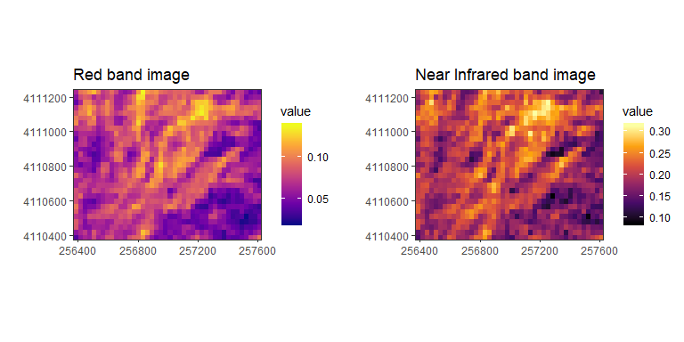

```r
redBand.df <- as.data.frame(redBand, xy = TRUE)
colnames(redBand.df)<-c('x', 'y', 'value')
plt.red<-ggplot() +
  geom_raster(data = redBand.df , aes(x = x, y = y, fill = value)) +
  scale_fill_viridis_c(option = 'plasma') +
  scale_x_continuous(expand = c(0,0))+
  scale_y_continuous(expand = c(0,0))+
  xlab('') + ylab('')+
  ggtitle('Red band image')+
  coord_quickmap()+
  theme_bw()

NIRBand.df <- as.data.frame(NIRBand, xy = TRUE)
colnames(NIRBand.df)<-c('x', 'y', 'value')
plt.nir<-ggplot() +
  geom_raster(data = NIRBand.df , aes(x = x, y = y, fill = value)) +
  scale_fill_viridis_c(option = 'inferno') +
  scale_x_continuous(expand = c(0,0))+
  scale_y_continuous(expand = c(0,0))+
  xlab('') + ylab('')+
  coord_quickmap()+
  ggtitle('Near Infrared band image')+
theme_bw()
ggarrange(plt.red, plt.nir)
```

# 6 NDVI Calculation example

Let’s calculate NDVI

```r
ndvi <- (NIRBand - redBand)/(NIRBand + redBand)
print(ndvi)
```

```
## class       : RasterLayer
## dimensions  : 29, 42, 1218  (nrow, ncol, ncell)
## resolution  : 30, 30  (x, y)
## extent      : 256365, 257625, 4110375, 4111245  (xmin, xmax, ymin, ymax)
## coord. ref. : +proj=utm +zone=11 +datum=WGS84 +units=m +no_defs +ellps=WGS84 +towgs84=0,0,0
## data source : in memory
## names       : layer
## values      : 0.3097251, 0.6905607  (min, max)
```

Let’s plot rastar for NDVI

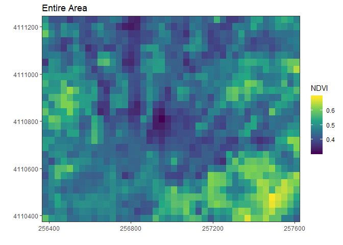

```r
plt.NDVI<-ggrasterPlot(ndvi, 'NDVI', 'Entire Area',colorScheme =  'virdis')
plt.NDVI
```

Let’s create a histogram of the NDVI:

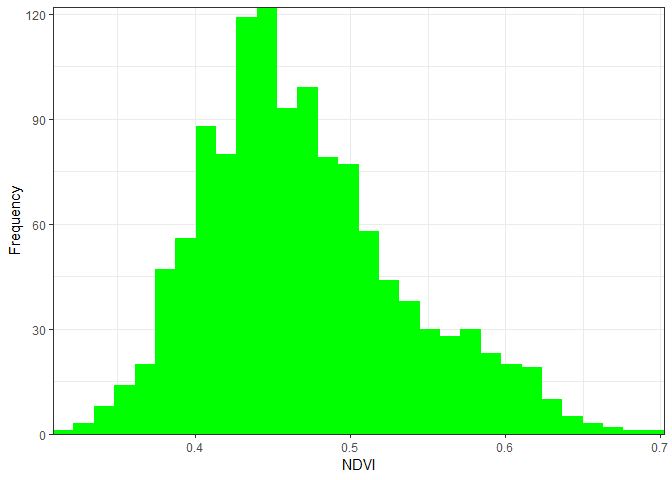

```r
  ndvi.df <- as.data.frame(ndvi, xy = TRUE)
  colnames(ndvi.df)<-c('x', 'y', 'NDVI')
ggplot() +
  geom_histogram(data = ndvi.df, aes(NDVI), fill='green')+
  xlab('NDVI') + ylab('Frequency')+
  scale_x_continuous(expand = c(0,0))+
  scale_y_continuous(expand = c(0,0))+
  theme_bw()
```

To calculate the average NDVI for whole raster, NDVI raster needs to convert as data matrix. Such can be done vis `rasterToPoints()` with argument raster as

```r
dataMatrix <- rasterToPoints(ndvi)
```

Let’s see what the table has

```r
str(dataMatrix)
```

```
##  num [1:1218, 1:3] 256380 256410 256440 256470 256500 ...
##  - attr(*, "dimnames")=List of 2
##   ..$ : NULL
##   ..$ : chr [1:3] "x" "y" "layer"
```

```r
head(dataMatrix)
```

```
##           x       y     layer
## [1,] 256380 4111230 0.4969136
## [2,] 256410 4111230 0.4074303
## [3,] 256440 4111230 0.4093173
## [4,] 256470 4111230 0.4197272
## [5,] 256500 4111230 0.3723543
## [6,] 256530 4111230 0.4074962
```

Since columns named `x` and `y` correspond to geo-coordinates, third column is obvisouly NDVI. In order to find the average value of NDVI, third column is used in `mean()` function

```r
NDVI.avg <- mean(dataMatrix[,3])
print(NDVI.avg)
```

```
## [1] 0.470304
```

# 7 Temporal Analysis

## 7.1 Loading series of rasters and calculating NDVI

```r
dateList = c('20180126', '20180202', '20180218', '20180306', '20180126', '20180202',
             '20180306', '20180218', '20180126', '20180202', '20180306', '20180202',
             '20180126', '20180218', '20180202', '20180306', '20180218', '20180306',
             '20180218', '20180306', '20180126', '20180218', '20180126', '20180218')
fileList = paste(dateList, '.tif', sep = '')
fileList
```

```
##  [1] "20180126.tif" "20180202.tif" "20180218.tif" "20180306.tif"
##  [5] "20180126.tif" "20180202.tif" "20180306.tif" "20180218.tif"
##  [9] "20180126.tif" "20180202.tif" "20180306.tif" "20180202.tif"
## [13] "20180126.tif" "20180218.tif" "20180202.tif" "20180306.tif"
## [17] "20180218.tif" "20180306.tif" "20180218.tif" "20180306.tif"
## [21] "20180126.tif" "20180218.tif" "20180126.tif" "20180218.tif"
```

```r
nFiles = length(fileList)
nFiles
```

```
## [1] 24
```

```r
NDVI.ts <- data.frame(id = 1:nFiles)
for (i in 1:nFiles) {
  imageFileNameI <- paste('Data/', fileList[i], sep = '')
  rasterImg <- stack(imageFileNameI)
  redBand.Indv<- rasterImg[[3]]
  NIRBand.Indv<- rasterImg[[4]]
  NDVI.Indv <- NDVI(NIRBand.Indv, redBand.Indv)
  dataMatrix <- rasterToPoints(NDVI.Indv)
  NDVI.ts$NDVI[i] <- mean(dataMatrix[,3])
}
```

## 7.2 Saving into csvFile

```r
write.csv(NDVI.ts, file = 'testNDVI.csv', row.names = F)
```

## 7.3 Loading NDVI time series

```r
readTs <- read.csv('testNDVI.csv', header = TRUE)
startDate = as.Date('2018-01-26')
endDate = as.Date('2019-02-01')
dateVec = seq(startDate, endDate, by = '16 day')
readTs$DATE = dateVec
```

## 7.4 Visualizing temporal dynamics

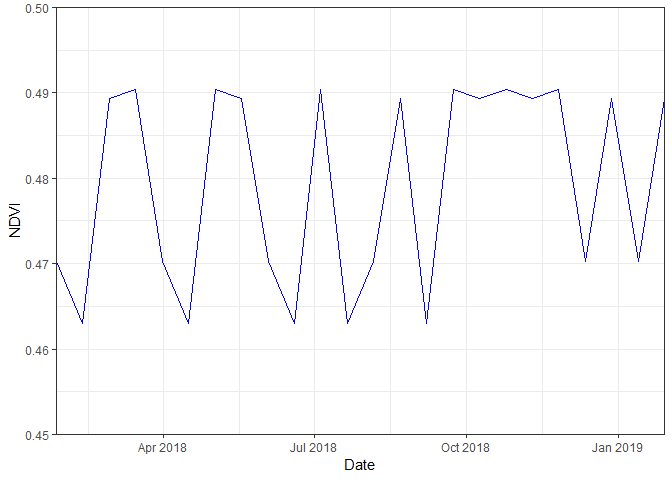

```r
ggplot(data = readTs)+
  geom_line(aes(x=DATE, y = NDVI), color ='blue')+
  xlab('Date') + ylab('NDVI')+
  scale_y_continuous(expand = c(0,0), limits = c(0.45, 0.5))+
  scale_x_date(expand = c(0,0))+
  theme_bw()
```

# 8 Spatial Analysis

## 8.1 Information about location

```r
dataMatrix <- rasterToPoints(ndvi)
xcoord = dataMatrix[,1]
ycoord = dataMatrix[,2]
maxX <- max(dataMatrix[,1])
maxY <- max(dataMatrix[,2])
minX <- min(dataMatrix[,1])
minY <- min(dataMatrix[,2])
```

## 8.2 Croping extent

Let’s define corner of left bottom half of the image

```r
midX = (minX+maxX)/2
midY = (minY+maxY)/2
cropArea1 <- getcropArea(minX, midX,minY, midY)
cropArea2 <- getcropArea(midX, maxX,minY, midY)
cropArea3 <- getcropArea(minX, midX,midY, maxY)
cropArea4 <- getcropArea(midX, maxX,midY, maxY)
crop_extent1 = extent(minX, midX, minY, midY)
crop_extent2 <- extent(midX, maxX,minY, midY)
crop_extent3 <- extent(minX, midX,midY, maxY)
crop_extent4 <- extent(midX, maxX,midY, maxY)
```

Superimpose crop area boundary over the image

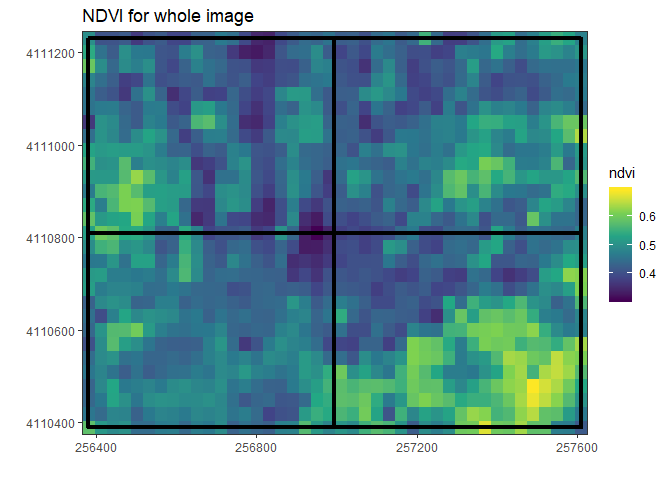

```r
ndvi.df <- as.data.frame(ndvi, xy = TRUE)
colnames(ndvi.df)<-c('x', 'y', 'ndvi')
plt.NDVI<-ggplot() +
  geom_raster(data = ndvi.df , aes(x = x, y = y, fill = ndvi)) +
  geom_rect(data=cropArea1, mapping=aes(xmin=minX, xmax=midX,
                                           ymin=minY, ymax=midY),
            color="black", alpha=0, size = 1.5) +
  geom_rect(data=cropArea2, mapping=aes(xmin=midX, xmax=maxX,
                                           ymin=minY, ymax=midY),
            color="black", alpha=0, size = 1.5) +
  geom_rect(data=cropArea3, mapping=aes(xmin=minX, xmax=midX,
                                           ymin=midY, ymax=maxY),
            color="black", alpha=0, size = 1.5) +
  geom_rect(data=cropArea4, mapping=aes(xmin=midX, xmax=maxX,
                                           ymin=midY, ymax=maxY),
            color="black", alpha=0, size = 1.5) +
  scale_fill_viridis_c(option = 'viridis') +
  scale_x_continuous(expand = c(0,0))+
  scale_y_continuous(expand = c(0,0))+
  xlab('') + ylab('')+
  coord_quickmap()+
  ggtitle('NDVI for whole image')+
theme_bw()
plt.NDVI
```

```r
imgCrop1 <- crop(ndvi, crop_extent1)
meanNDVI1 = meanNDVI(imgCrop1)
print(meanNDVI1)
```

```
## [1] 0.4623415
```

```r
imgCrop2 <- crop(ndvi, crop_extent2)
meanNDVI2 = meanNDVI(imgCrop2)
print(meanNDVI2)
```

```
## [1] 0.5069105
```

```r
imgCrop3 <- crop(ndvi, crop_extent3)
meanNDVI3 = meanNDVI(imgCrop3)
print(meanNDVI3)
```

```
## [1] 0.4508264
```

```r
imgCrop4 <- crop(ndvi, crop_extent4)
meanNDVI4 = meanNDVI(imgCrop4)
print(meanNDVI4)
```

```
## [1] 0.4595218
```

## 8.3 Visualizing spatial dynamics

Once again, recall original NDVI data frame and plot the histogram for entire area

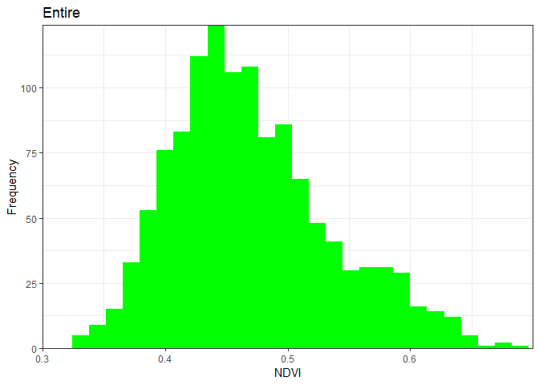

```r
# Entire
pltall<-ggrasterHist(ndvi, 'NDVI')
pltall+ggtitle('Entire')
```

Let’s have seperate ggplots for individual sections

```r
# bottom left
plt.corner1<-ggrasterHist(imgCrop1, 'NDVI')
```

```r
#  bottom right
plt.corner2<-ggrasterHist(imgCrop2, 'NDVI')
```

```r
# top left
plt.corner4<-ggrasterHist(imgCrop3, 'NDVI')
```

```r
#  top right
plt.corner3<-ggrasterHist(imgCrop4, 'NDVI')
```

Now, combine them using `ggarrange` as

[figure not shown]

```r
ggarrange(plt.corner3+ggtitle('Top Left')+geom_vline(xintercept = meanNDVI3),
          plt.corner4+ggtitle('Top Right')+geom_vline(xintercept = meanNDVI4),
          plt.corner1+ggtitle('Bottom Left')+geom_vline(xintercept = meanNDVI1),
          plt.corner2+ggtitle('Bottom Right')+geom_vline(xintercept = meanNDVI2),
          nrow = 2, ncol = 2)
```